# Bootstrap Simulation

##### **Overview**

This script creates a function for running a simple bootstrap simulation from a given input. Bootstrap simulations work by pulling a series of random events from the past and stringing them together to produce a possible future outcome.You can specify how many **months.back** you want the simulation to pull samples from and how many **months.forward** you want the simulation to produce. If you want to use recent history make **months.back** a small number. If you want to project your simulation far out into the future, make **months.forward** a larger number. Specify the number of simulations with **trials**.

The function produces 2 plots. The first plot shows the original data as well as each individual simulated **trials**. The second plot is a distribution of the return or total percent change from the last historical value and the last **months.forward** value for each simulation.

The **alpha** parameter controls how transparent the lines are in the first graph.

##### **Required Packages**

- ggplot2
- gridExtra
- scales
- reshape2

##### **Tasks**

- Boostrap simulation
- Advanced ggploting
- Reshaping data

Access the script on my [Github Page](https://github.com/JestonBlu/DataScience)

```r
library(ggplot2)
library(reshape2)
library(scales)
library(grid)
library(gridExtra)

data("BJsales")
```

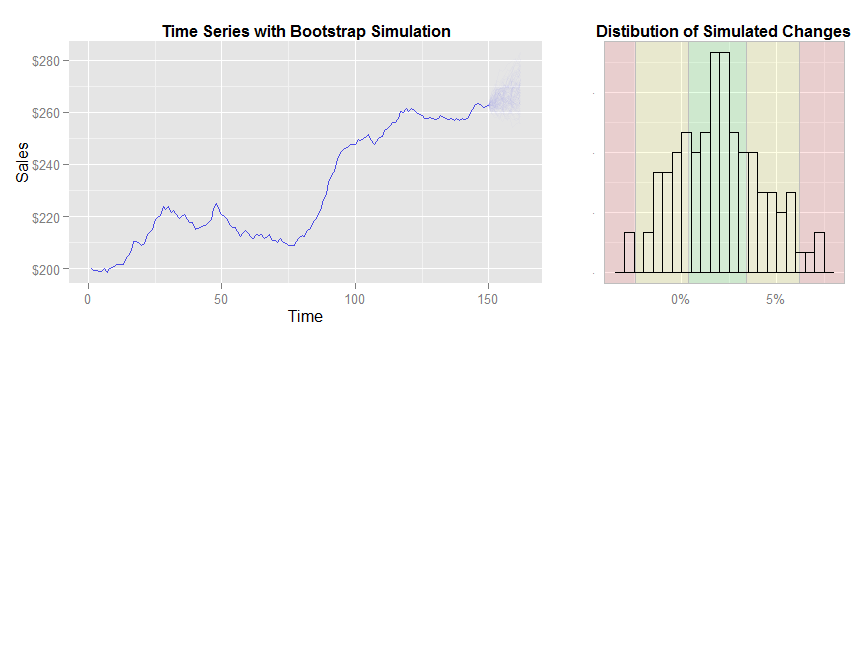

```r
boot.plot(BJsales, trials = 100, months.back = 12, months.forward = 12, alph = .01)
```

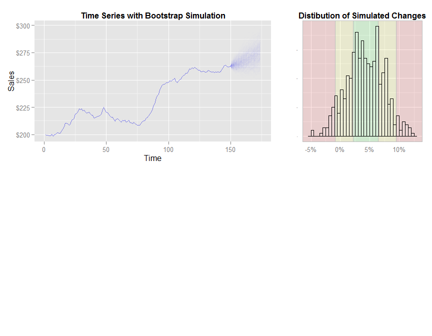

```r
boot.plot(BJsales, trials = 500, months.back = 24, months.forward = 24, alph = .005)
```

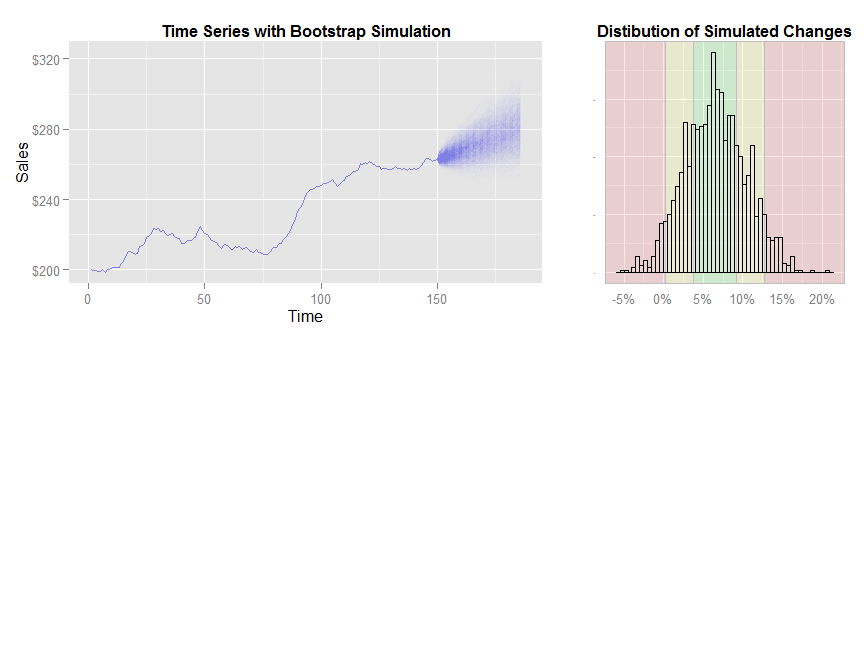

```r
boot.plot(BJsales, trials = 1500, months.back = 36, months.forward = 36, alph = .005)
```